# Introduction to Neural Networks: Bank Churn prediction

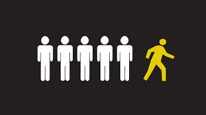

# 4th Project - Bank Churn

# **Developed by Samad KHANI - November, 2023**

## Problem Statement

### Context

Businesses like banks which provide service have to worry about problem of 'Customer Churn' i.e. customers leaving and joining another service provider. It is important to understand which aspects of the service influence a customer's decision in this regard. Management can concentrate efforts on improvement of service, keeping in mind these priorities.

### Objective

You as a Data scientist with the bank need to build a neural network based classifier that can determine whether a customer will leave the bank or not in the next 6 months.

### Data Dictionary:

- CustomerId: Unique ID which is assigned to each customer
- Surname: Last name of the customer
- CreditScore: It defines the credit history of the customer.
- Geography: A customer’s location
- Gender: It defines the Gender of the customer
- Age: Age of the customer
- Tenure: Number of years for which the customer has been with the bank
- NumOfProducts: refers to the number of products that a customer has purchased through the bank.
- Balance: Account balance
- HasCrCard: It is a categorical variable which decides whether the customer has credit card or not.
- EstimatedSalary: Estimated salary
- isActiveMember: Is is a categorical variable which decides whether the customer is active member of the bank or not ( Active member in the sense, using bank products regularly, making transactions etc )
- Exited : whether or not the customer left the bank within six month. It can take two values **0=No ( Customer did not leave the bank )** 1=Yes ( Customer left the bank )

```python
# Mounting the Google Drive
from google.colab import drive
drive.mount('/content/drive')
```

## Importing necessary libraries

```python
!pip install tensorflow==2.9.1  # bringing in tensorflow
```

[output not shown]

```python
# Libraries to help with reading and manipulating data
import pandas as pd
import numpy as np

# Library to split data
from sklearn.model_selection import train_test_split

# Library to encode the variables
from sklearn import preprocessing

# To plot confusion matrix
from sklearn.metrics import confusion_matrix

# Importing metrics
from sklearn import metrics

# Importing GridSearchCV
from sklearn.model_selection import GridSearchCV

# Importing roc_curve to plot
from sklearn.metrics import roc_curve
from matplotlib import pyplot

# Library to import to standardize the data
from sklearn.preprocessing import StandardScaler

# To import different metrics
from sklearn import metrics
import random

# Libraries to help with data visualization
import matplotlib.pyplot as plt
import seaborn as sns

# Library to avoid the warnings
import warnings
warnings.filterwarnings("ignore")
```

```python
# NN related libs
# TensorFlow and Keras
import tensorflow as tf
from tensorflow import keras
from tensorflow.keras import backend
from tensorflow.keras.models import Sequential
from tensorflow.keras.layers import Dense, Dropout
from tensorflow.keras.wrappers.scikit_learn import KerasClassifier

# Importing SMOTE
from imblearn.over_sampling import SMOTE

# Importing classback API
from keras import callbacks
```

## Loading the dataset

```python
# Import the dataset as panda dataframe
df = pd.read_csv('/content/drive/MyDrive/Colab Notebooks/AI training materials/Intro to neural network/Project/Churn.csv')
```

## Data Overview

### Understand the shape of the dataset

```python
# Shape of dataframe
print('The dataset is a ', df.shape , ' matrix')
```

```
The dataset is a  (10000, 14)  matrix
```

```python
# Display the header
df.head()
```

|  | RowNumber | CustomerId | Surname | CreditScore | Geography | Gender | Age | Tenure | Balance | NumOfProducts | HasCrCard | IsActiveMember | EstimatedSalary | Exited |
| --- | --- | --- | --- | --- | --- | --- | --- | --- | --- | --- | --- | --- | --- | --- |
| 0 | 1 | 15634602 | Hargrave | 619 | France | Female | 42 | 2 | 0.00 | 1 | 1 | 1 | 101348.88 | 1 |
| 1 | 2 | 15647311 | Hill | 608 | Spain | Female | 41 | 1 | 83807.86 | 1 | 0 | 1 | 112542.58 | 0 |
| 2 | 3 | 15619304 | Onio | 502 | France | Female | 42 | 8 | 159660.80 | 3 | 1 | 0 | 113931.57 | 1 |
| 3 | 4 | 15701354 | Boni | 699 | France | Female | 39 | 1 | 0.00 | 2 | 0 | 0 | 93826.63 | 0 |
| 4 | 5 | 15737888 | Mitchell | 850 | Spain | Female | 43 | 2 | 125510.82 | 1 | 1 | 1 | 79084.10 | 0 |

```python
# Display the tail
df.tail()
```

|  | RowNumber | CustomerId | Surname | CreditScore | Geography | Gender | Age | Tenure | Balance | NumOfProducts | HasCrCard | IsActiveMember | EstimatedSalary | Exited |
| --- | --- | --- | --- | --- | --- | --- | --- | --- | --- | --- | --- | --- | --- | --- |
| 9995 | 9996 | 15606229 | Obijiaku | 771 | France | Male | 39 | 5 | 0.00 | 2 | 1 | 0 | 96270.64 | 0 |
| 9996 | 9997 | 15569892 | Johnstone | 516 | France | Male | 35 | 10 | 57369.61 | 1 | 1 | 1 | 101699.77 | 0 |
| 9997 | 9998 | 15584532 | Liu | 709 | France | Female | 36 | 7 | 0.00 | 1 | 0 | 1 | 42085.58 | 1 |
| 9998 | 9999 | 15682355 | Sabbatini | 772 | Germany | Male | 42 | 3 | 75075.31 | 2 | 1 | 0 | 92888.52 | 1 |
| 9999 | 10000 | 15628319 | Walker | 792 | France | Female | 28 | 4 | 130142.79 | 1 | 1 | 0 | 38190.78 | 0 |

### Check the data types of the columns for the dataset

```python
# Get the data type
df.info()
```

```
<class 'pandas.core.frame.DataFrame'>
RangeIndex: 10000 entries, 0 to 9999
Data columns (total 14 columns):
 #   Column           Non-Null Count  Dtype
---  ------           --------------  -----
 0   RowNumber        10000 non-null  int64
 1   CustomerId       10000 non-null  int64
 2   Surname          10000 non-null  object
 3   CreditScore      10000 non-null  int64
 4   Geography        10000 non-null  object
 5   Gender           10000 non-null  object
 6   Age              10000 non-null  int64
 7   Tenure           10000 non-null  int64
 8   Balance          10000 non-null  float64
 9   NumOfProducts    10000 non-null  int64
 10  HasCrCard        10000 non-null  int64
 11  IsActiveMember   10000 non-null  int64
 12  EstimatedSalary  10000 non-null  float64
 13  Exited           10000 non-null  int64
dtypes: float64(2), int64(9), object(3)
memory usage: 1.1+ MB
```

### Observations:

The dataset includes the following columns with 10,000 non-null values each:

- RowNumber: Integer type.
- CustomerId: Integer type.
- Surname: Object type.
- CreditScore: Integer type.
- Geography: Object type.
- Gender: Object type.
- ...
- Exited: Integer type.

### Checking for unique values for each of the column

```python
# Get unique values
df.nunique()
```

```
RowNumber          10000
CustomerId         10000
Surname             2932
CreditScore          460
Geography              3
Gender                 2
Age                   70
Tenure                11
Balance             6382
NumOfProducts          4
HasCrCard              2
IsActiveMember         2
EstimatedSalary     9999
Exited                 2
dtype: int64
```

### Observations:

- Some columns have only a few unique values, means are highly categorised.

### Statistical Summary

```python
# Statistics of data
df.describe().T
```

|  | count | mean | std | min | 25% | 50% | 75% | max |
| --- | --- | --- | --- | --- | --- | --- | --- | --- |
| RowNumber | 10000.0 | 5.000500e+03 | 2886.895680 | 1.00 | 2500.75 | 5.000500e+03 | 7.500250e+03 | 10000.00 |
| CustomerId | 10000.0 | 1.569094e+07 | 71936.186123 | 15565701.00 | 15628528.25 | 1.569074e+07 | 1.575323e+07 | 15815690.00 |
| CreditScore | 10000.0 | 6.505288e+02 | 96.653299 | 350.00 | 584.00 | 6.520000e+02 | 7.180000e+02 | 850.00 |
| Age | 10000.0 | 3.892180e+01 | 10.487806 | 18.00 | 32.00 | 3.700000e+01 | 4.400000e+01 | 92.00 |
| Tenure | 10000.0 | 5.012800e+00 | 2.892174 | 0.00 | 3.00 | 5.000000e+00 | 7.000000e+00 | 10.00 |
| Balance | 10000.0 | 7.648589e+04 | 62397.405202 | 0.00 | 0.00 | 9.719854e+04 | 1.276442e+05 | 250898.09 |
| NumOfProducts | 10000.0 | 1.530200e+00 | 0.581654 | 1.00 | 1.00 | 1.000000e+00 | 2.000000e+00 | 4.00 |
| HasCrCard | 10000.0 | 7.055000e-01 | 0.455840 | 0.00 | 0.00 | 1.000000e+00 | 1.000000e+00 | 1.00 |
| IsActiveMember | 10000.0 | 5.151000e-01 | 0.499797 | 0.00 | 0.00 | 1.000000e+00 | 1.000000e+00 | 1.00 |
| EstimatedSalary | 10000.0 | 1.000902e+05 | 57510.492818 | 11.58 | 51002.11 | 1.001939e+05 | 1.493882e+05 | 199992.48 |
| Exited | 10000.0 | 2.037000e-01 | 0.402769 | 0.00 | 0.00 | 0.000000e+00 | 0.000000e+00 | 1.00 |

### Duplicated values check

```python
# Check if any rows duplicated
df.duplicated().sum()
```

```
0
```

### Drop the columns which are unique for all users like IDs, names, and rownumbers

```python
# Drop the unique columns
df.drop(columns=["CustomerId", "Surname", "RowNumber"], inplace=True)
```

### Observations:

Columns with entirely unique values don't add any information, therefore dropped.

## Exploratory Data Analysis

- EDA is an important part of any project involving data.
- It is important to investigate and understand the data better before building a model with it.
- A few questions have been mentioned below which will help you approach the analysis in the right manner and generate insights from the data.
- A thorough analysis of the data, in addition to the questions mentioned below, should be done.

**Questions**:

1. What is the distribution of the credit score of customers? Are there any noticeable patterns or outliers in the distribution?
2. How many active members are there with the bank?
3. How are the different customer attributes correlated to each other?
4. Who is churning more when compared to males and females?
5. Customers from which geographical part are churning more?

```python
#   Generate a combined boxplot and histogram for a given feature.

"""
Parameters:
    - data: DataFrame
    - feature: Column in the DataFrame
    - figsize: Size of the figure (default (12,8))
    - kde: Whether to show the density curve (default False)
    - bins: Number of bins for the histogram (default None)
"""
def Plot_histogram_boxplot(data, feature, figsize=(12, 8), kde=False, bins=None):

    # Create a figure with two subplots (boxplot and histogram)
    f, (ax_box, ax_hist) = plt.subplots(
        nrows=2,
        sharex=True,
        gridspec_kw={"height_ratios": (0.25, 0.75)},
        figsize=figsize
    )

    # Boxplot with mean indicator
    sns.boxplot(
        data=data, x=feature, ax=ax_box, showmeans=True, color="orange"
    )

    # Histogram with KDE (Kernel Density Estimate) if specified
    sns.histplot(
        data=data, x=feature, kde=kde, ax=ax_hist, bins=bins, color="green", palette="fall"
    ) if bins else sns.histplot(
        data=data, x=feature, kde=kde, ax=ax_hist, color="green", palette="fall"
    )

    # Add mean and median lines to the histogram
    ax_hist.axvline(
        data[feature].mean(), color="red", linestyle="--", label='Mean'
    )
    ax_hist.axvline(
        data[feature].median(), color="black", linestyle="-", label='Median'
    )

    # Set legend for the histogram subplot
    ax_hist.legend()

    # Display the plots
    plt.show()
```

#### CreditScore

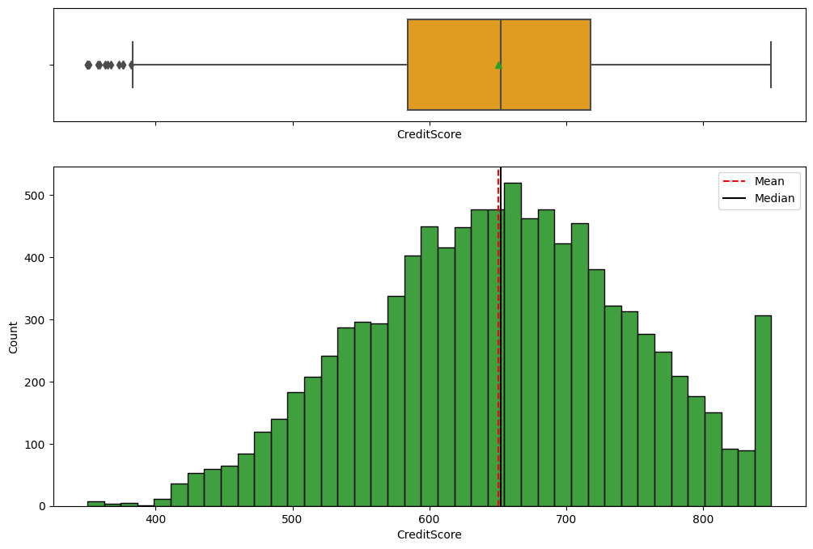

```python
Plot_histogram_boxplot(df,'CreditScore')
```

### Observations:

- The distribution of Credit Scores exhibits a nearly normal pattern, where the mean and median closely coincide. Nonetheless, there are outliers, especially in the lower range of credit scores.

#### Age

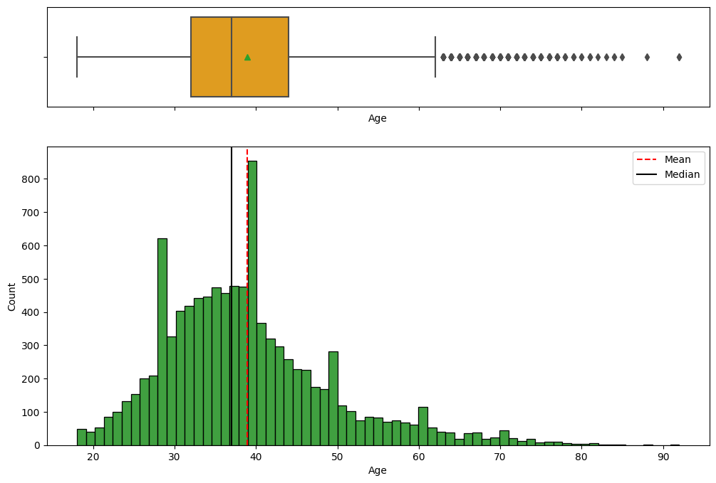

```python
Plot_histogram_boxplot(df,'Age')
```

### Observations:

#### Balance

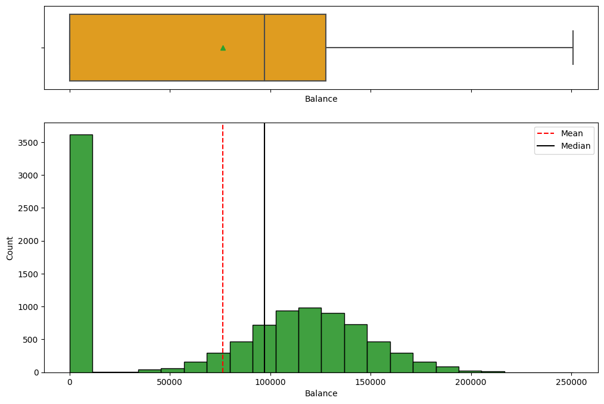

```python
Plot_histogram_boxplot(df,'Balance')
```

### Observations:

#### Salary

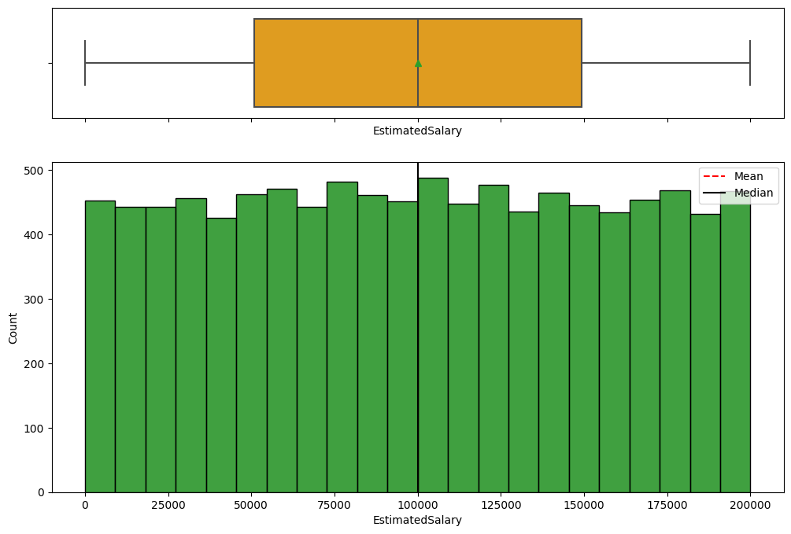

```python
Plot_histogram_boxplot(df,'EstimatedSalary')
```

### Observations:

```python
  # Generate a labeled barplot with optional percentage display.

"""
Parameters:
    - data: DataFrame
    - feature: Column in the DataFrame
    - perc: Whether to display percentages instead of count (default is False)
    - n: Displays the top n category levels (default is None, i.e., display all levels)
"""

def Plot_labeled_barplot(data, feature, perc=False, n=None):

    total = len(data[feature])  # Length of the column
    count = data[feature].nunique()

    # Set the figure size based on the number of unique values or specified 'n'
    plt.figure(figsize=(count + 1, 5)) if n is None else plt.figure(figsize=(n + 1, 5))

    plt.xticks(rotation=0, fontsize=10)

    # Create a countplot with optional ordering based on value counts
    ax = sns.countplot(
        data=data,
        x=feature,
        palette="summer",
        order=data[feature].value_counts().index[:n].sort_values(),
    )

    # Annotate each bar with count or percentage
    for p in ax.patches:
        if perc:
            label = "{:.1f}%".format(
                100 * p.get_height() / total
            )  # Percentage of each category level
        else:
            label = p.get_height()  # Count of each category level

        x = p.get_x() + p.get_width() / 2  # Width of the plot
        y = p.get_height()  # Height of the plot

        # Annotate the percentage or count
        ax.annotate(
            label,
            (x, y),
            ha="center",
            va="center",
            size=12,
            xytext=(0, 5),
            textcoords="offset points",
        )

    # Show the plot
    plt.show()

# Example usage:
# labeled_barplot(dataset, 'Geography', perc=True, n=5)
```

#### Exited

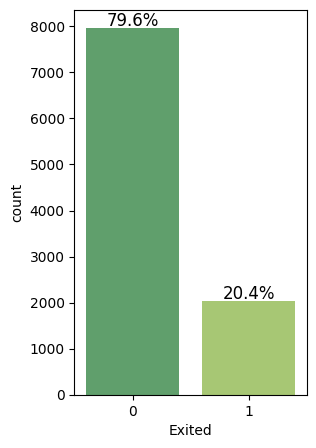

```python
Plot_labeled_barplot(df, "Exited", perc=True)
```

### Observations:

- Around 20% of the overall customer base consists of individuals who have exited.

#### Geography

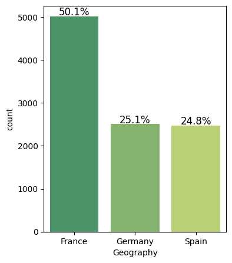

```python
Plot_labeled_barplot(df, "Geography", perc=True)
```

### Observations:

#### Gender

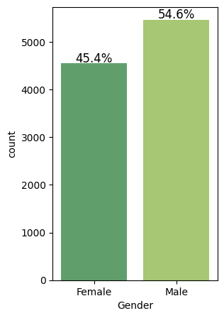

```python
Plot_labeled_barplot(df, "Gender", perc=True)
```

### Observations:

- Upon analyzing the gender distribution, it's apparent that there is a greater number of males, making up approximately 54% of the total customer base, compared to females.

#### Tenure

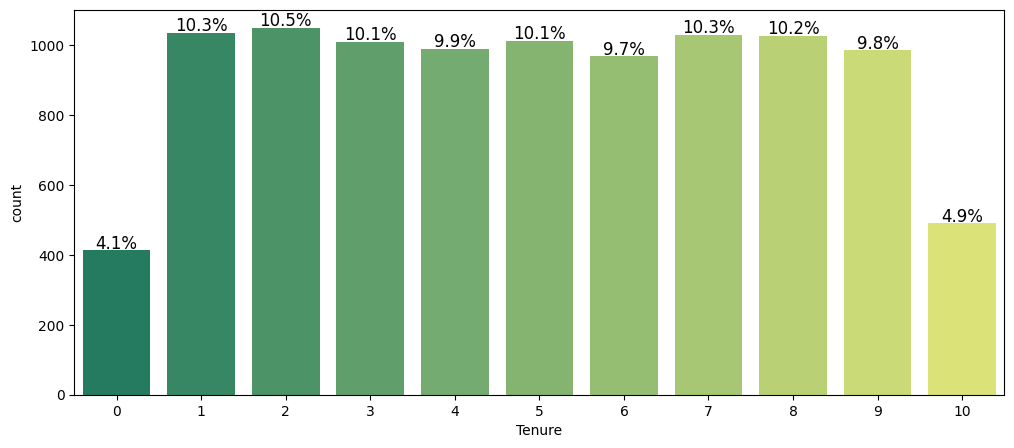

```python
Plot_labeled_barplot(df, "Tenure", perc=True)
```

### Observations:

- Most customers have a tenure with the bank ranging from 1 to 9 years, with a minority falling into the categories of less than 1 year or more than 9 years.

#### Products

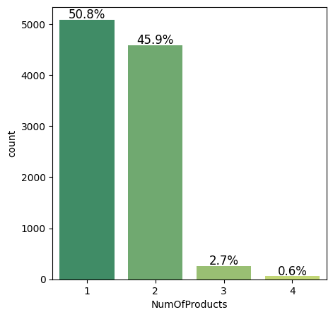

```python
Plot_labeled_barplot(df, "NumOfProducts", perc=True)
```

### Observations:

- Around 95% of customers have either 1 or 2 products with the bank, whereas less than 5% of customers possess more than 2 products with the bank.

#### Card

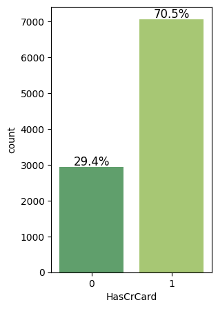

```python
Plot_labeled_barplot(df, "HasCrCard", perc=True)
```

### Observations:

- Approximately 70% of customers have a credit card with the bank.

#### Is Active Member

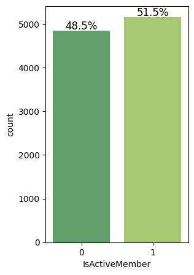

```python
Plot_labeled_barplot(df, "IsActiveMember", perc=True)
```

### Observations:

- The count of active customers slightly exceeds that of non-active customers, suggesting that these individuals actively participate in bank products and consistently conduct transactions.